# *Support Vector Machine (SVM) - Supervised Machine Learning*

## *What is Support Vector Machine?*

*Support Vector Machine (SVM) is a supervised machine learning algorithm which can be used for both classification or regression challenges. However, it is mostly used in classification problems. In the SVM algorithm, we plot each data item as a point in n-dimensional space (where n is number of features you have) with the value of each feature being the value of a particular coordinate. Then, we perform classification by finding the hyper-plane that differentiates the two classes very well.*

*SVM algorithm can perform really well with both linearly separable and non-linearly separable datasets. Even with a limited amount of data, the support vector machine algorithm does not fail to show its magic.*

*The objective of the Support Vector Machine is to find the best splitting boundary between data. In two dimensional space, you can think of this like the best fit line that divides your dataset. With a Support Vector Machine, we're dealing in vector space, thus the separating line is actually a separating hyperplane. The best separating hyperplane is defined as the hyperplane that contains the "widest" margin (maximum margin) between support vectors. The hyperplane may also be referred to as a decision boundary. The easiest way to convey this is through images:*

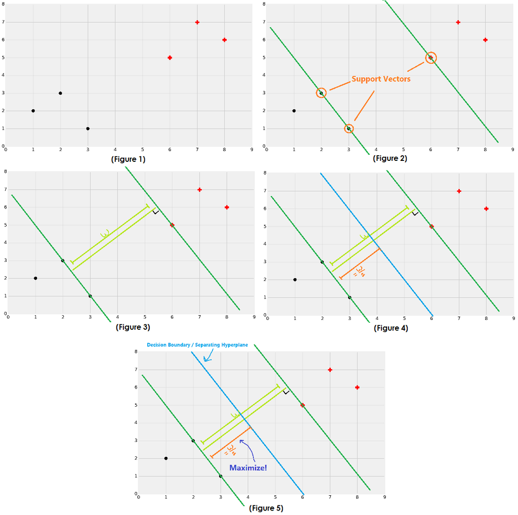

*The followings are important concepts in SVM:*

### *Support Vectors*

*Support vectors are special data points in the dataset. They are responsible for the construction of the hyperplane and are the closest points to the hyperplane. If these points were removed, the position of the hyperplane would be altered. The hyperplane has decision boundaries around it. And, the support vectors help in decreasing and increasing the size of the boundaries. They are the main components in making an SVM.*

### *Hyperplane*

*The hyperplane is the central line in the diagram above. In this case, the hyperplane is a line because the dimension is 2-D. If we had a 3-D plane, the hyperplane would have been a 2-D plane itself. There is a lot of mathematics involved in studying the hyperplane. We will be looking at that. But, to understand a hyperplane we need to imagine it first. Imagine there is a feature space (a blank piece of paper). Now, imagine a line cutting through it from the center. That is the hyperplane. The math equation for the hyperplane is a linear equation.*

$$a0 + a1x1 + a2x2 + ……. + anxn$$

*This is the equation. Here a0 is the intercept of the hyperplane. Also, a1 and a2 define the first and second axes respectively. X1 and X2 are for two dimensions. Let us assume that the equation is equal to E. So if the data points lie beneath the hyperplane then E<0. If they are above it, the E>=0. This is how we classify data using a hyperplane.*

### *Margin*

*It may be defined as the gap between two lines on the closet data points of different classes. It can be calculated as the perpendicular distance from the line to the support vectors. Large margin is considered as a good margin and small margin is considered as a bad margin.*

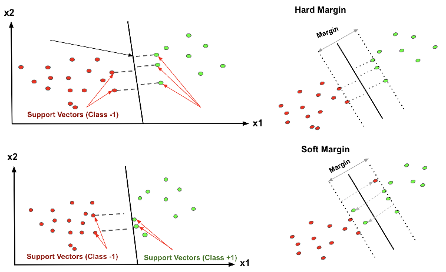

#### *Hard Margin*

*If the training data is linearly separable, we can select two parallel hyperplanes that separate the two classes of data, so that the distance between them is as large as possible.*

#### *Soft Margin*

*As most of the real-world data are not fully linearly separable, we will allow some margin violation to occur, which is called soft margin classification. It is better to have a large margin, even though some constraints are violated. Margin violation means choosing a hyperplane, which can allow some data points to stay in either the incorrect side of the hyperplane and between the margin and the correct side of the hyperplane.*

### *Decision Boundaries*

*Decision boundaries in SVM are the two lines that we see alongside the hyperplane. The distance between the two light-toned lines is called the margin. An optimal or best hyperplane form when the margin size is maximum. The SVM algorithm adjusts the hyperplane and its margins according to the support vectors.*

## *How does SVM work?*

### *Linear Data*

*The basic principle behind the working of Support vector machines is simple – Create a hyperplane that separates the dataset into classes. Let us start with a sample problem. Suppose that for a given dataset, you have to classify red squares from blue circles. Your goal is to create a line that classifies the data into two classes, creating a distinction between red squares and blue circles.*

*While one can hypothesize a clear line that separates the two classes, there can be many lines that can do this job. Therefore, there is not a single line that you can agree on which can perform this task. Let us visualize some of the lines that can differentiate between the two classes as follows –*

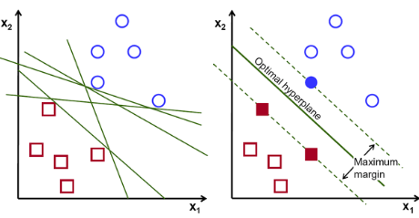

*In the above visualizations, we have many green lines. Which one do you think would better differentiate the data into two classes? If you choose the any one line, then it is the ideal line that partitions the two classes properly. However, we still have not concretized the fact that it is the universal line that would classify our data most efficiently.*

*Then some green line cannot be the ideal line as it lies too close to the red class. Therefore, it does not provide a proper generalization which is our end goal.*

*According to SVM, we have to find the points that lie closest to both the classes. These points are known as **support vectors**. In the next step, we find the proximity between our dividing plane and the support vectors. The distance between the points and the dividing line is known as **margin**. The aim of an SVM algorithm is to maximize this very margin. When the margin reaches its maximum, the hyperplane becomes the optimal one.*

*The SVM model tries to enlarge the distance between the two classes by creating a well-defined **decision boundary**. In the above case, our hyperplane divided the data. While our data was in 2 dimensions, the hyperplane was of 1 dimension. For higher dimensions, say, an n-dimensional Euclidean Space, we have an n-1 dimensional subset that divides the space into two disconnected components.*

### *Non-Linear Data*

*Now this example was easy, since clearly the data was linearly separable — we could draw a straight line to separate red and blue. Sadly, usually things aren’t that simple. Take a look at this case (Figure 1):*

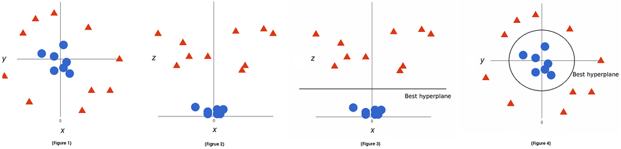

*It’s pretty clear that there’s not a linear decision boundary (a single straight line that separates both tags). However, the vectors are very clearly segregated and it looks as though it should be easy to separate them.*

*So here’s what we’ll do: we will add a third dimension. Up until now we had two dimensions: x and y. We create a new z dimension, and we rule that it be calculated a certain way that is convenient for us: z = x² + y² (you’ll notice that’s the equation for a circle).*

## *Intiution Behind SVM*

### *Linear Algebra*

#### *Vectors*

*Vectors are mathematical quantity which has both magnitude and direction. A point in the 2D plane can be represented as a vector between origin and the point.*

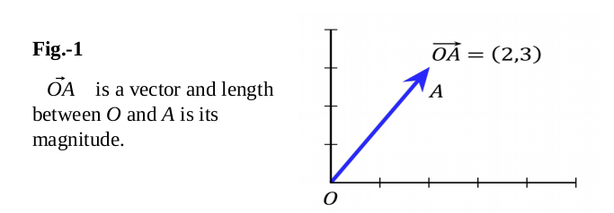

#### *Length of Vectors*

*Length of vectors are also called as norms. It tells how far vectors are from the origin.*

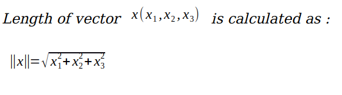

#### *Direction of vectors*

*Direction of vector*

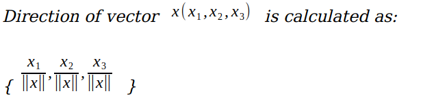

#### *Dot Product*

*Dot product between two vectors is a scalar quantity. It tells how to vectors are related.*

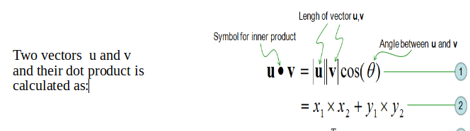

### *Mathematical Interpretation of Optimal Hyperplane*

*Hyperplane is line divides data point into two classes, written as formula for a line:*

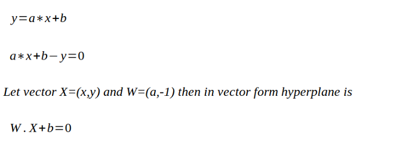

#### *Margin Calculations*

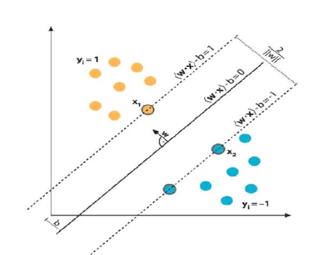

*We consider D=2 to keep explanation simple and data points are linearly separable, The hyperplane w.x+b=0 can be described as:*

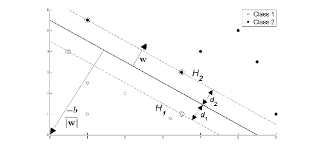

*Support vectors examples are closest to optimal hyperplane and the aim of the SVM is to orientate this hyperplane as far as possible from the closest member of the both classes.*

*From the above Fig , SVM problem can be formulated as,*

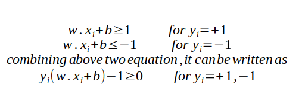

*we have two hyperplane H1 and H2 passing through the support vectors of +1 and -1 class respectively. so*

$$w.x+b=-1 :H1$$$$w.x+b=1 :H2$$

*And distance between H1 hyperplane and origin is (-1-b)/|w| and distance between H2 hyperplane and origin is (1–b)/|w|. So, margin can be given as*

$$M=(1-b)/|w|-(-1-b)/|w|$$$$M=2/|w|$$

*Where M is nothing but twice of the margin. So margin can be written as 1/|w|. As, optimal hyperplane maximize the margin, then the SVM objective is boiled down to fact of maximizing the term 1/|w|*

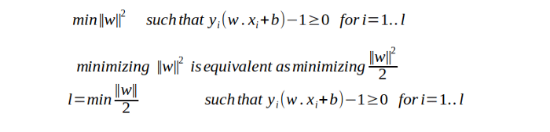

*[Reference](https://medium.com/@ankitnitjsr13/math-behind-support-vector-machine-svm-5e7376d0ee4d0)*

#### *Optimization*

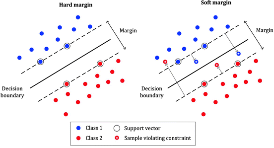

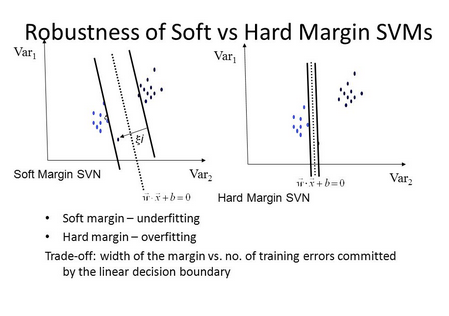

_To avoid these issues it is preferable to use more flexible model. As most of real world data are not fully linearly separable, we will allow some margin violation to occur. It is better to have large margin, even though some constraints is violated. Margin violation means choosing an hyperplane, which can allow some data points to stay in either in between the margin area or in the incorrect side of hyperplane,which is contrast to hard margin classification task . This type of classification are called as *soft margin classification*._

*what does it mean Mathematically??*

*we will relax the constrains of the equation slightly to allow the margin violation to occur with the help of positive slack variable ξi. so now above equation can be written as,*

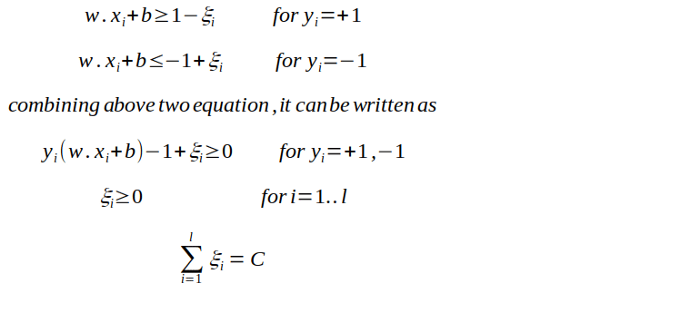

*$ξi$ actually tells where the ith observation is located relative to hyperplane and margin,for 0<ξi≤1, then observation is between incorrect side of margin and correct side of hyperplane.This is margin violation. for ξi>1 ,observation is on the incorrect side of both hyperplane and margin, and point is misclassified. And in the soft margin classification task, the observation is on the incorrect side of margin have penalty which increases as distance from it increases.*

*$C$ is the parameter which controls the trade-off between length of margin and number of the misclassification on the training data. For C=0, It is not letting any misclassification to occur which is a nothing but hard margin classification and it result in narrow margin, For C>0, it mean no more than C observation can violate the margin, as C increases margin also widens. The correct value of C is decided by cross-validation and it is this parameter only, that can result in bias-variance trade-off in SVM. If the value of C =0, which results in high variance but if the value of C= ∞ it results in high bias.*

*The soft margin optimization will be similar to that hard margin optimization task, but it will include an additional penalty term which penalize margin when a data point is mis-classified. The loss function is given as,*

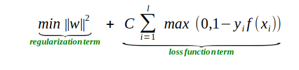

*The loss function here is called **'Hinge Loss'**. Hinge loss, is to penalize misclassifications. It measures the error due to misclassification (or data points being closer to the classification boundary than the margin).*

*“Hinge” describes the fact that the error is 0 if the data point is classified correctly (and is not too close to the decision boundary).*

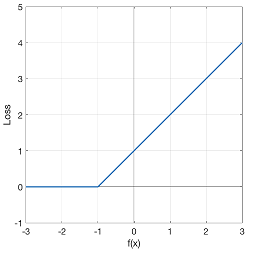

*When the true class is -1 (as in your example), the hinge loss looks like this in the graph.*

*We need to minimise the above loss function to find the max-margin classifier.*

*[Video Reference](https://www.youtube.com/watch?v=Js3GLb1xPhc&t=203s)*

*[Reference](https://www.youtube.com/watch?v=1NxnPkZM9bc)*

## *SVM Kernels*

_In practice, SVM algorithm is implemented with kernel that transforms an input data space into the required form. SVM uses a technique called the *KERNEL TRICK* in which kernel takes a low dimensional input space and transforms it into a higher dimensional space. In simple words, kernel converts non-separable problems into separable problems by adding more dimensions to it. It makes SVM more powerful, flexible and accurate. The following are some of the types of kernels used by SVM._

### *Linear Kernel*

*It can be used as a dot product between any two observations. The formula of linear kernel is as below −*

$$K(x,xi)=sum(x∗xi)$$

*From the above formula, we can see that the product between two vectors say 𝑥 & 𝑥𝑖 is the sum of the multiplication of each pair of input values.*

### *Polynomial Kernel*

*It is more generalized form of linear kernel and distinguish curved or nonlinear input space. Following is the formula for polynomial kernel −*

$$k(X,Xi)=1+sum(X∗Xi)^d$$

*Here d is the degree of polynomial, which we need to specify manually in the learning algorithm.*

### *Radial Basis Function (RBF) Kernel*

*RBF kernel, mostly used in SVM classification, maps input space in indefinite dimensional space. Following formula explains it mathematically −*

$$K(x,xi)=exp(−gamma∗sum(x−xi^2))$$

*Here, gamma ranges from 0 to 1. We need to manually specify it in the learning algorithm. A good default value of gamma is 0.1.*

_[Reference](https://www.youtube.com/watch?v=Qc5IyLW_hns&t=64s)_

```python
# Packages / libraries

import os #provides functions for interacting with the operating system

import numpy as np
import pandas as pd
from matplotlib import pyplot as plt
import seaborn as sns

%matplotlib inline

import warnings
warnings.filterwarnings('ignore')
```

## *SVM Functions in sklearn*

*Support Vector Classifier*

```
SVC(C=1.0,
    kernel='rbf',
    degree=3,
    gamma='scale',
    max_iter=-1,
    decision_function_shape='ovr',
    random_state=None)
```

*Support Vector Regression*

```
SVR(kernel='rbf',
    degree=3,
    gamma='scale',
    C=1.0,
    max_iter=-1)
```

## *Modeling using sklearn*

```python
data = pd.read_csv(r'C:\Users\PiyushSin\Desktop\datasets\wisconsin.csv')
data.head()
```

|  | id | diagnosis | radius_mean | texture_mean | perimeter_mean | area_mean | smoothness_mean | compactness_mean | concavity_mean | concave points_mean | ... | texture_worst | perimeter_worst | area_worst | smoothness_worst | compactness_worst | concavity_worst | concave points_worst | symmetry_worst | fractal_dimension_worst | Unnamed: 32 |
| --- | --- | --- | --- | --- | --- | --- | --- | --- | --- | --- | --- | --- | --- | --- | --- | --- | --- | --- | --- | --- | --- |
| 0 | 842302 | M | 17.99 | 10.38 | 122.80 | 1001.0 | 0.11840 | 0.27760 | 0.3001 | 0.14710 | ... | 17.33 | 184.60 | 2019.0 | 0.1622 | 0.6656 | 0.7119 | 0.2654 | 0.4601 | 0.11890 | NaN |
| 1 | 842517 | M | 20.57 | 17.77 | 132.90 | 1326.0 | 0.08474 | 0.07864 | 0.0869 | 0.07017 | ... | 23.41 | 158.80 | 1956.0 | 0.1238 | 0.1866 | 0.2416 | 0.1860 | 0.2750 | 0.08902 | NaN |
| 2 | 84300903 | M | 19.69 | 21.25 | 130.00 | 1203.0 | 0.10960 | 0.15990 | 0.1974 | 0.12790 | ... | 25.53 | 152.50 | 1709.0 | 0.1444 | 0.4245 | 0.4504 | 0.2430 | 0.3613 | 0.08758 | NaN |
| 3 | 84348301 | M | 11.42 | 20.38 | 77.58 | 386.1 | 0.14250 | 0.28390 | 0.2414 | 0.10520 | ... | 26.50 | 98.87 | 567.7 | 0.2098 | 0.8663 | 0.6869 | 0.2575 | 0.6638 | 0.17300 | NaN |
| 4 | 84358402 | M | 20.29 | 14.34 | 135.10 | 1297.0 | 0.10030 | 0.13280 | 0.1980 | 0.10430 | ... | 16.67 | 152.20 | 1575.0 | 0.1374 | 0.2050 | 0.4000 | 0.1625 | 0.2364 | 0.07678 | NaN |

5 rows × 33 columns

```python
predictor = data.loc[:,~data.columns.isin(['diagnosis','id','Unnamed: 32'])]
target = data[['diagnosis']]
```

```python
from sklearn.preprocessing import MinMaxScaler

sclr = MinMaxScaler()
predictor_sc = sclr.fit_transform(predictor)
predictor_sc.shape
```

```
(569, 30)
```

```python
from sklearn.model_selection import train_test_split

x_train_sc,x_test_sc, y_train, y_test = train_test_split(predictor_sc, target, test_size = 0.30, random_state=101)
print("Scaled train and test split")
print("x_train ",x_train_sc.shape)
print("x_test ",x_test_sc.shape)
print("y_train ",y_train.shape)
print("y_test ",y_test.shape)
```

```
Scaled train and test split
x_train  (398, 30)
x_test  (171, 30)
y_train  (398, 1)
y_test  (171, 1)
```

### *Linear Kernel*

```python
from sklearn.svm import SVC

svm_model = SVC(kernel='linear')
svm_model
```

```
SVC(kernel='linear')
```

```python
from sklearn.metrics import accuracy_score

model2 = svm_model.fit(x_train_sc, y_train)
y_pred2 = svm_model.predict(x_test_sc)

print('Accuracy Score')
print(accuracy_score(y_test,y_pred2))
```

```
Accuracy Score
0.9707602339181286
```

#### *RBF Kernel*

```python
svm3 = SVC(C=1.0, cache_size=200, class_weight=None, coef0=0.0,
           decision_function_shape='ovr', degree=3, gamma='auto',
           kernel='rbf', max_iter=-1, probability=False,
           random_state=None, shrinking=True, tol=0.001, verbose=False)
svm3
```

```
SVC(gamma='auto')
```

```python
model3 = svm3.fit(x_train_sc, y_train)
y_pred3 = svm3.predict(x_test_sc)

print('Accuracy Score')
print(accuracy_score(y_test, y_pred3))
```

```
Accuracy Score
0.935672514619883
```

#### *Polynomial Kernel*

```python
svm4 = SVC(C=1.0, cache_size=200, class_weight=None,
           coef0=0.0,decision_function_shape='ovr',
           degree=3, gamma='auto', kernel='poly',
           max_iter=-1, probability=False, random_state=None,
           shrinking=True, tol=0.001, verbose=False)
svm4
```

```
SVC(gamma='auto', kernel='poly')
```

```python
model4 = svm4.fit(x_train_sc, y_train)
y_pred4 = svm4.predict(x_test_sc)

print('Accuracy Score')
print(accuracy_score(y_test,y_pred4))
```

```
Accuracy Score
0.6198830409356725
```

## *Parameter Tuning*

*SVM parameters improve the quality of the hyperplane and are inserted as normal parameters in the Python code. These parameters determine the shape of the hyperplane, the transition of data between decision boundaries, etc. There are overall four main types of parameters that we should know. These are:*

- *Kernel Parameters*
- *Gamma Parameters*
- *C Parameters*
- *Degree Parameters*

### *Kernel Parameters*

*In Kernel parameters, also we have four types which are linear, RBF, polynomial and sigmoid. The kernel parameters determine the shape and structure of the hyperplane. By tuning, we can set the kernel type and the model adapts to it.*

### *Gamma Parameters*

*The gamma parameter is for non-linear hyperplanes. Here, the kernel value is RBF, polynomial or sigmoid. This parameter tries to fit in all the data. Lower value of Gamma creates a loose fit of the training dataset. On the other hand, a high value of gamma allows the model to get fit more appropriately. A low value of gamma will only provide consideration to the nearby points for the calculation of a separate plane. However, the high value of gamma will consider all the data-points to calculate the final separation line.*

### *C Parameters*

*The C parameter is more like a penalty parameter. It tells us that if the value of C is high then, the datapoints further away from the plane are also important to us. This makes us include them also and this leads to overfitting.*

### *Degree Parameters*

*Finally, the degree parameter. This parameter uses ‘poly’ as the kernel value. The degree parameter helps to find the hyperplane for splitting data. Then the degree of the polynomial helps in this. The more the degree of polynomial increases, the more training time it takes.*

*By tuning all these values, one can control the hyperplane as well as the model of SVM.*

#### *Linear Kernel Tuning*

```python
from sklearn.model_selection import cross_val_score, GridSearchCV

C_range=list(range(1,26))
acc_score=[]

for c in C_range:
    svc = SVC(kernel='linear', C=c)
    scores = cross_val_score(svc, predictor_sc, target, cv=10, scoring='accuracy')
    acc_score.append(scores.mean())

print(acc_score)
```

```
[0.9771303258145363, 0.9771303258145363, 0.9806390977443608, 0.982393483709273, 0.9788847117794484, 0.9788847117794486, 0.9806390977443608, 0.9788847117794484, 0.9788847117794484, 0.9788847117794484, 0.9806390977443608, 0.9788847117794484, 0.9788847117794484, 0.9771303258145363, 0.9771303258145363, …
```

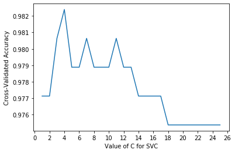

```python
plt.plot(C_range,acc_score)
plt.xticks(np.arange(0,27,2))

plt.xlabel('Value of C for SVC')
plt.ylabel('Cross-Validated Accuracy')
```

*From the plot we can see that accuracy has been close to 98% somewhere in between C=4 and C=5 and then it drops.*

```python
#Taking a close look at the cross-validation accuracy in the range C(4,5)
C_range=list(np.arange(4,5,0.2))
acc_score=[]

for c in C_range:
    svc = svm.SVC(kernel='linear', C=c)
    scores = cross_val_score(svc, predictor_sc, target, cv=10,
    scoring='accuracy')
    acc_score.append(scores.mean())
print(acc_score)
```

```
[0.982393483709273, 0.9806390977443608, 0.9788847117794484, 0.9788847117794484, 0.9788847117794484]
```

#### *RBF Kernel Tuning*

```python
gamma_range=[0.0001,0.001,0.01,0.1,1,10,100]
acc_score=[]
for g in gamma_range:
    svc = svm.SVC(kernel='rbf', gamma=g)
    scores = cross_val_score(svc, predictor_sc, target, cv=10,
    scoring='accuracy')
    acc_score.append(scores.mean())
print(acc_score)
```

```
[0.6274122807017544, 0.6274122807017544, 0.9192042606516291, 0.9560463659147869, 0.9806390977443608, 0.9419172932330826, 0.6274122807017544]
```

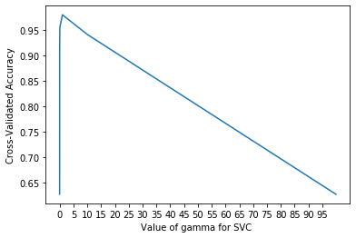

```python
# plotting the value of gamma for SVM versus the cross-validated accuracy
plt.plot(gamma_range,acc_score)
plt.xlabel('Value of gamma for SVC ')
plt.xticks(np.arange(0.0001,100,5))
plt.ylabel('Cross-Validated Accuracy')
```

```python
gamma_range=list(np.arange(0.1,5,0.1))
acc_score=[]

for g in gamma_range:
    svc = svm.SVC(kernel='rbf', gamma=g)
    scores = cross_val_score(svc, predictor_sc, target, cv=10, scoring='accuracy')
    acc_score.append(scores.mean())
print(acc_score)
```

```
[0.9560463659147869, 0.9718358395989973, 0.975344611528822, 0.9736215538847117, 0.9806390977443608, 0.9806390977443608, 0.9806390977443608, 0.9806390977443608, 0.9806390977443608, 0.9806390977443608, 0.9788847117794486, 0.9753759398496239, 0.9753759398496239, 0.9753759398496239, 0.9753759398496239, …
```

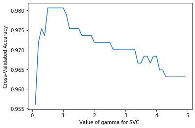

```python
gamma_range=list(np.arange(0.1,5,0.1))

plt.plot(gamma_range,acc_score)
plt.xlabel('Value of gamma for SVC ')
#plt.xticks(np.arange(0.0001,5,5))
plt.ylabel('Cross-Validated Accuracy')
```

*The highest cross-validated accuracy for rbf kernel remains constant in between gamma=0.5 and gamma=1.*

#### *Poly Kernel Tuning*

```python
degree=[2,3,4,5,6]
acc_score=[]

for d in degree:
    svc = svm.SVC(kernel='poly', degree=d)
    scores = cross_val_score(svc, predictor_sc, target, cv=10, scoring='accuracy')
    acc_score.append(scores.mean())
print(acc_score)
```

```
[0.9806390977443608, 0.9718671679197994, 0.9683583959899748, 0.9666666666666666, 0.9595864661654134]
```

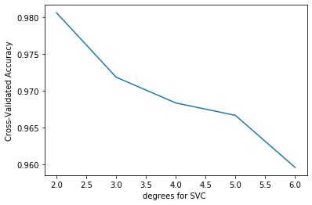

```python
plt.plot(degree,acc_score)
plt.xlabel('degrees for SVC ')
plt.ylabel('Cross-Validated Accuracy')
```

*Score is high for second degree polynomial. There is drop in the accuracy score as degree of polynomial increases.Thus increase in polynomial degree results in high complexity of the model.*

## *Use Case - Face Recognition Modeling*

```python
from sklearn.datasets import fetch_lfw_people

faces = fetch_lfw_people(min_faces_per_person=60)
print(faces.target_names)
print(faces.images.shape)
```

```
['Ariel Sharon' 'Colin Powell' 'Donald Rumsfeld' 'George W Bush'
 'Gerhard Schroeder' 'Junichiro Koizumi' 'Tony Blair']
(1277, 62, 47)
```

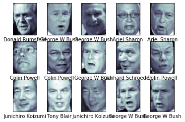

```python
fig, ax = plt.subplots(3, 5)
for i, axi in enumerate(ax.flat):
    axi.imshow(faces.images[i], cmap='bone')
    axi.set(xticks=[], yticks=[],
            xlabel=faces.target_names[faces.target[i]])
```

```python
from sklearn.svm import SVC
from sklearn.decomposition import PCA
from sklearn.pipeline import make_pipeline

pca = PCA(n_components=150, svd_solver='randomized', whiten=True, random_state=42)
svc = SVC(kernel='rbf', class_weight='balanced')
model = make_pipeline(pca, svc)
```

```python
from sklearn.model_selection import train_test_split

Xtrain, Xtest, ytrain, ytest = train_test_split(faces.data, faces.target,
                                                random_state=42)
```

```python
from sklearn.model_selection import GridSearchCV

param_grid = {'svc__C': [1, 5, 10, 50],
              'svc__gamma': [0.0001, 0.0005, 0.001, 0.005]}
grid = GridSearchCV(model, param_grid)

%time grid.fit(Xtrain, ytrain)
print(grid.best_params_)
```

```
Wall time: 1min 28s
{'svc__C': 10, 'svc__gamma': 0.005}
```

```python
model = grid.best_estimator_
yfit = model.predict(Xtest)
```

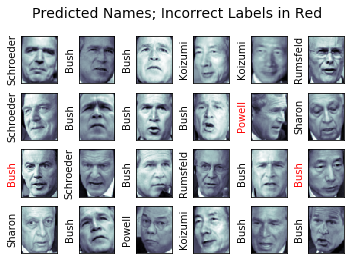

```python
fig, ax = plt.subplots(4, 6)
for i, axi in enumerate(ax.flat):
    axi.imshow(Xtest[i].reshape(62, 47), cmap='bone')
    axi.set(xticks=[], yticks=[])
    axi.set_ylabel(faces.target_names[yfit[i]].split()[-1],
                   color='black' if yfit[i] == ytest[i] else 'red')
fig.suptitle('Predicted Names; Incorrect Labels in Red', size=14);
```

```python
from sklearn.metrics import classification_report

print(classification_report(ytest, yfit,
                            target_names=faces.target_names))
```

```
                   precision    recall  f1-score   support

     Ariel Sharon       0.88      0.54      0.67        13
     Colin Powell       0.77      0.86      0.81        66
  Donald Rumsfeld       0.95      0.60      0.73        30
    George W Bush       0.82      0.96      0.88       139
Gerhard Schroeder       1.00      0.75      0.86        24
Junichiro Koizumi       1.00      0.71      0.83        17
       Tony Blair       0.93      0.81      0.86        31

         accuracy                           0.84       320
        macro avg       0.91      0.75      0.81       320
     weighted avg       0.86      0.84      0.84       320
```

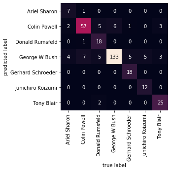

```python
from sklearn.metrics import confusion_matrix

mat = confusion_matrix(ytest, yfit)
sns.heatmap(mat.T, square=True, annot=True, fmt='d', cbar=False,
            xticklabels=faces.target_names,
            yticklabels=faces.target_names)
plt.xlabel('true label')
plt.ylabel('predicted label');
```

## *Use Case - Gender Recognition by Voice*

```python
df = pd.read_csv(r'C:\Users\PiyushSin\Desktop\datasets\voice_gender.csv')
df.head()
```

|  | meanfreq | sd | median | Q25 | Q75 | IQR | skew | kurt | sp.ent | sfm | ... | centroid | meanfun | minfun | maxfun | meandom | mindom | maxdom | dfrange | modindx | label |
| --- | --- | --- | --- | --- | --- | --- | --- | --- | --- | --- | --- | --- | --- | --- | --- | --- | --- | --- | --- | --- | --- |
| 0 | 0.059781 | 0.064241 | 0.032027 | 0.015071 | 0.090193 | 0.075122 | 12.863462 | 274.402906 | 0.893369 | 0.491918 | ... | 0.059781 | 0.084279 | 0.015702 | 0.275862 | 0.007812 | 0.007812 | 0.007812 | 0.000000 | 0.000000 | male |
| 1 | 0.066009 | 0.067310 | 0.040229 | 0.019414 | 0.092666 | 0.073252 | 22.423285 | 634.613855 | 0.892193 | 0.513724 | ... | 0.066009 | 0.107937 | 0.015826 | 0.250000 | 0.009014 | 0.007812 | 0.054688 | 0.046875 | 0.052632 | male |
| 2 | 0.077316 | 0.083829 | 0.036718 | 0.008701 | 0.131908 | 0.123207 | 30.757155 | 1024.927705 | 0.846389 | 0.478905 | ... | 0.077316 | 0.098706 | 0.015656 | 0.271186 | 0.007990 | 0.007812 | 0.015625 | 0.007812 | 0.046512 | male |
| 3 | 0.151228 | 0.072111 | 0.158011 | 0.096582 | 0.207955 | 0.111374 | 1.232831 | 4.177296 | 0.963322 | 0.727232 | ... | 0.151228 | 0.088965 | 0.017798 | 0.250000 | 0.201497 | 0.007812 | 0.562500 | 0.554688 | 0.247119 | male |
| 4 | 0.135120 | 0.079146 | 0.124656 | 0.078720 | 0.206045 | 0.127325 | 1.101174 | 4.333713 | 0.971955 | 0.783568 | ... | 0.135120 | 0.106398 | 0.016931 | 0.266667 | 0.712812 | 0.007812 | 5.484375 | 5.476562 | 0.208274 | male |

5 rows × 21 columns

```python
df.corr()
```

|  | meanfreq | sd | median | Q25 | Q75 | IQR | skew | kurt | sp.ent | sfm | mode | centroid | meanfun | minfun | maxfun | meandom | mindom | maxdom | dfrange | modindx |
| --- | --- | --- | --- | --- | --- | --- | --- | --- | --- | --- | --- | --- | --- | --- | --- | --- | --- | --- | --- | --- |
| meanfreq | 1.000000 | -0.739039 | 0.925445 | 0.911416 | 0.740997 | -0.627605 | -0.322327 | -0.316036 | -0.601203 | -0.784332 | 0.687715 | 1.000000 | 0.460844 | 0.383937 | 0.274004 | 0.536666 | 0.229261 | 0.519528 | 0.515570 | -0.216979 |
| sd | -0.739039 | 1.000000 | -0.562603 | -0.846931 | -0.161076 | 0.874660 | 0.314597 | 0.346241 | 0.716620 | 0.838086 | -0.529150 | -0.739039 | -0.466281 | -0.345609 | -0.129662 | -0.482726 | -0.357667 | -0.482278 | -0.475999 | 0.122660 |
| median | 0.925445 | -0.562603 | 1.000000 | 0.774922 | 0.731849 | -0.477352 | -0.257407 | -0.243382 | -0.502005 | -0.661690 | 0.677433 | 0.925445 | 0.414909 | 0.337602 | 0.251328 | 0.455943 | 0.191169 | 0.438919 | 0.435621 | -0.213298 |
| Q25 | 0.911416 | -0.846931 | 0.774922 | 1.000000 | 0.477140 | -0.874189 | -0.319475 | -0.350182 | -0.648126 | -0.766875 | 0.591277 | 0.911416 | 0.545035 | 0.320994 | 0.199841 | 0.467403 | 0.302255 | 0.459683 | 0.454394 | -0.141377 |
| Q75 | 0.740997 | -0.161076 | 0.731849 | 0.477140 | 1.000000 | 0.009636 | -0.206339 | -0.148881 | -0.174905 | -0.378198 | 0.486857 | 0.740997 | 0.155091 | 0.258002 | 0.285584 | 0.359181 | -0.023750 | 0.335114 | 0.335648 | -0.216475 |
| IQR | -0.627605 | 0.874660 | -0.477352 | -0.874189 | 0.009636 | 1.000000 | 0.249497 | 0.316185 | 0.640813 | 0.663601 | -0.403764 | -0.627605 | -0.534462 | -0.222680 | -0.069588 | -0.333362 | -0.357037 | -0.337877 | -0.331563 | 0.041252 |
| skew | -0.322327 | 0.314597 | -0.257407 | -0.319475 | -0.206339 | 0.249497 | 1.000000 | 0.977020 | -0.195459 | 0.079694 | -0.434859 | -0.322327 | -0.167668 | -0.216954 | -0.080861 | -0.336848 | -0.061608 | -0.305651 | -0.304640 | -0.169325 |
| kurt | -0.316036 | 0.346241 | -0.243382 | -0.350182 | -0.148881 | 0.316185 | 0.977020 | 1.000000 | -0.127644 | 0.109884 | -0.406722 | -0.316036 | -0.194560 | -0.203201 | -0.045667 | -0.303234 | -0.103313 | -0.274500 | -0.272729 | -0.205539 |
| sp.ent | -0.601203 | 0.716620 | -0.502005 | -0.648126 | -0.174905 | 0.640813 | -0.195459 | -0.127644 | 1.000000 | 0.866411 | -0.325298 | -0.601203 | -0.513194 | -0.305826 | -0.120738 | -0.293562 | -0.294869 | -0.324253 | -0.319054 | 0.198074 |
| sfm | -0.784332 | 0.838086 | -0.661690 | -0.766875 | -0.378198 | 0.663601 | 0.079694 | 0.109884 | 0.866411 | 1.000000 | -0.485913 | -0.784332 | -0.421066 | -0.362100 | -0.192369 | -0.428442 | -0.289593 | -0.436649 | -0.431580 | 0.211477 |
| mode | 0.687715 | -0.529150 | 0.677433 | 0.591277 | 0.486857 | -0.403764 | -0.434859 | -0.406722 | -0.325298 | -0.485913 | 1.000000 | 0.687715 | 0.324771 | 0.385467 | 0.172329 | 0.491479 | 0.198150 | 0.477187 | 0.473775 | -0.182344 |
| centroid | 1.000000 | -0.739039 | 0.925445 | 0.911416 | 0.740997 | -0.627605 | -0.322327 | -0.316036 | -0.601203 | -0.784332 | 0.687715 | 1.000000 | 0.460844 | 0.383937 | 0.274004 | 0.536666 | 0.229261 | 0.519528 | 0.515570 | -0.216979 |
| meanfun | 0.460844 | -0.466281 | 0.414909 | 0.545035 | 0.155091 | -0.534462 | -0.167668 | -0.194560 | -0.513194 | -0.421066 | 0.324771 | 0.460844 | 1.000000 | 0.339387 | 0.311950 | 0.270840 | 0.162163 | 0.277982 | 0.275154 | -0.054858 |
| minfun | 0.383937 | -0.345609 | 0.337602 | 0.320994 | 0.258002 | -0.222680 | -0.216954 | -0.203201 | -0.305826 | -0.362100 | 0.385467 | 0.383937 | 0.339387 | 1.000000 | 0.213987 | 0.375979 | 0.082015 | 0.317860 | 0.316486 | 0.002042 |
| maxfun | 0.274004 | -0.129662 | 0.251328 | 0.199841 | 0.285584 | -0.069588 | -0.080861 | -0.045667 | -0.120738 | -0.192369 | 0.172329 | 0.274004 | 0.311950 | 0.213987 | 1.000000 | 0.337553 | -0.243426 | 0.355390 | 0.359880 | -0.363029 |
| meandom | 0.536666 | -0.482726 | 0.455943 | 0.467403 | 0.359181 | -0.333362 | -0.336848 | -0.303234 | -0.293562 | -0.428442 | 0.491479 | 0.536666 | 0.270840 | 0.375979 | 0.337553 | 1.000000 | 0.099656 | 0.812838 | 0.811304 | -0.180954 |
| mindom | 0.229261 | -0.357667 | 0.191169 | 0.302255 | -0.023750 | -0.357037 | -0.061608 | -0.103313 | -0.294869 | -0.289593 | 0.198150 | 0.229261 | 0.162163 | 0.082015 | -0.243426 | 0.099656 | 1.000000 | 0.026640 | 0.008666 | 0.200212 |
| maxdom | 0.519528 | -0.482278 | 0.438919 | 0.459683 | 0.335114 | -0.337877 | -0.305651 | -0.274500 | -0.324253 | -0.436649 | 0.477187 | 0.519528 | 0.277982 | 0.317860 | 0.355390 | 0.812838 | 0.026640 | 1.000000 | 0.999838 | -0.425531 |
| dfrange | 0.515570 | -0.475999 | 0.435621 | 0.454394 | 0.335648 | -0.331563 | -0.304640 | -0.272729 | -0.319054 | -0.431580 | 0.473775 | 0.515570 | 0.275154 | 0.316486 | 0.359880 | 0.811304 | 0.008666 | 0.999838 | 1.000000 | -0.429266 |
| modindx | -0.216979 | 0.122660 | -0.213298 | -0.141377 | -0.216475 | 0.041252 | -0.169325 | -0.205539 | 0.198074 | 0.211477 | -0.182344 | -0.216979 | -0.054858 | 0.002042 | -0.363029 | -0.180954 | 0.200212 | -0.425531 | -0.429266 | 1.000000 |

```python
df.isnull().sum()
```

```
meanfreq    0
sd          0
median      0
Q25         0
Q75         0
IQR         0
skew        0
kurt        0
sp.ent      0
sfm         0
mode        0
centroid    0
meanfun     0
minfun      0
maxfun      0
meandom     0
mindom      0
maxdom      0
dfrange     0
modindx     0
label       0
dtype: int64
```

```python
print("Total number of labels: {}".format(df.shape[0]))
print("Number of male: {}".format(df[df.label == 'male'].shape[0]))
print("Number of female: {}".format(df[df.label == 'female'].shape[0]))
```

```
Total number of labels: 3168
Number of male: 1584
Number of female: 1584
```

```python
X=df.iloc[:, :-1]
X.head()
```

|  | meanfreq | sd | median | Q25 | Q75 | IQR | skew | kurt | sp.ent | sfm | mode | centroid | meanfun | minfun | maxfun | meandom | mindom | maxdom | dfrange | modindx |
| --- | --- | --- | --- | --- | --- | --- | --- | --- | --- | --- | --- | --- | --- | --- | --- | --- | --- | --- | --- | --- |
| 0 | 0.059781 | 0.064241 | 0.032027 | 0.015071 | 0.090193 | 0.075122 | 12.863462 | 274.402906 | 0.893369 | 0.491918 | 0.000000 | 0.059781 | 0.084279 | 0.015702 | 0.275862 | 0.007812 | 0.007812 | 0.007812 | 0.000000 | 0.000000 |
| 1 | 0.066009 | 0.067310 | 0.040229 | 0.019414 | 0.092666 | 0.073252 | 22.423285 | 634.613855 | 0.892193 | 0.513724 | 0.000000 | 0.066009 | 0.107937 | 0.015826 | 0.250000 | 0.009014 | 0.007812 | 0.054688 | 0.046875 | 0.052632 |
| 2 | 0.077316 | 0.083829 | 0.036718 | 0.008701 | 0.131908 | 0.123207 | 30.757155 | 1024.927705 | 0.846389 | 0.478905 | 0.000000 | 0.077316 | 0.098706 | 0.015656 | 0.271186 | 0.007990 | 0.007812 | 0.015625 | 0.007812 | 0.046512 |
| 3 | 0.151228 | 0.072111 | 0.158011 | 0.096582 | 0.207955 | 0.111374 | 1.232831 | 4.177296 | 0.963322 | 0.727232 | 0.083878 | 0.151228 | 0.088965 | 0.017798 | 0.250000 | 0.201497 | 0.007812 | 0.562500 | 0.554688 | 0.247119 |
| 4 | 0.135120 | 0.079146 | 0.124656 | 0.078720 | 0.206045 | 0.127325 | 1.101174 | 4.333713 | 0.971955 | 0.783568 | 0.104261 | 0.135120 | 0.106398 | 0.016931 | 0.266667 | 0.712812 | 0.007812 | 5.484375 | 5.476562 | 0.208274 |

```python
from sklearn.preprocessing import LabelEncoder
y=df.iloc[:,-1]

# Encode label category
# male -> 1
# female -> 0

gender_encoder = LabelEncoder()
y = gender_encoder.fit_transform(y)
y
```

```
array([1, 1, 1, ..., 0, 0, 0])
```

```python
# Scale the data to be between -1 and 1
from sklearn.preprocessing import StandardScaler
scaler = StandardScaler()
scaler.fit(X)
X = scaler.transform(X)
```

```python
from sklearn.model_selection import train_test_split
X_train, X_test, y_train, y_test = train_test_split(X, y, test_size=0.2, random_state=1)
```

```python
# Default Parameters

svc=SVC()
svc.fit(X_train,y_train)
y_pred=svc.predict(X_test)

print('Accuracy Score:')
print(accuracy_score(y_test,y_pred))
```

```
Accuracy Score:
0.9763406940063092
```

```python
pred = svc.predict(X_test)
pred[0:10]
```

```
array([0, 0, 0, 0, 0, 0, 0, 0, 1, 1])
```

```python
# Linear Parameters

svc=SVC(kernel='linear')
svc.fit(X_train,y_train)
y_pred=svc.predict(X_test)

print('Accuracy Score:')
print(accuracy_score(y_test,y_pred))
```

```
Accuracy Score:
0.9779179810725552
```

```python
pred = svc.predict(X_test)
pred[0:10]
```

```
array([0, 0, 0, 0, 0, 0, 0, 0, 1, 1])
```

```python
# RBF Parameters

svc=SVC(kernel='rbf')
svc.fit(X_train,y_train)
y_pred=svc.predict(X_test)

print('Accuracy Score:')
print(accuracy_score(y_test,y_pred))
```

```
Accuracy Score:
0.9763406940063092
```

```python
pred = svc.predict(X_test)
pred[0:10]
```

```
array([0, 0, 0, 0, 0, 0, 0, 0, 1, 1])
```

```python
# Poly Parameters

svc=SVC(kernel='poly')
svc.fit(X_train,y_train)
y_pred=svc.predict(X_test)

print('Accuracy Score:')
print(accuracy_score(y_test,y_pred))
```

```
Accuracy Score:
0.9589905362776026
```

```python
pred = svc.predict(X_test)
pred[0:10]
```

```
array([0, 0, 0, 0, 0, 0, 0, 0, 1, 1])
```

*Further, we can apply different hyperparameter tuning techniques.*

## *Support Vector Regression*

*In support vector regression we try to fit the error with in some threshold.*

*[Reference](https://www.youtube.com/watch?v=dxu-beXTb3c)*

```python
# Importing the dataset
dataset = pd.read_csv(r'C:\Users\PiyushSin\Desktop\datasets\Position_Salaries.csv')

X = dataset.iloc[:, 1:2].values
y = dataset.iloc[:, 2].values
```

```python
dataset.head()
```

|  | Position | Level | Salary |
| --- | --- | --- | --- |
| 0 | Business Analyst | 1 | 45000 |
| 1 | Junior Consultant | 2 | 50000 |
| 2 | Senior Consultant | 3 | 60000 |
| 3 | Manager | 4 | 80000 |
| 4 | Country Manager | 5 | 110000 |

```python
Y = y.reshape(-1,1)

# Feature Scaling
from sklearn.preprocessing import StandardScaler

sc_X = StandardScaler()
sc_Y = StandardScaler()
X = sc_X.fit_transform(X)
Y = sc_Y.fit_transform(Y)
```

```python
# Fitting the SVR model to the dataset
from sklearn.svm import SVR

regressor = SVR(kernel = 'rbf')
regressor.fit(X,Y)
```

```
SVR()
```

```python
# Predicting a new result with the Polynomial Regression

Y_Pred = sc_Y.inverse_transform(regressor.predict(sc_X.transform(np.array([6.5]).reshape(-1,1))))
```

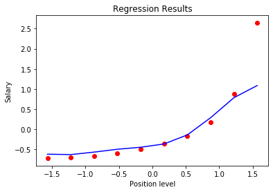

```python
# Visualising the Regression results

plt.scatter(X,Y, color = 'red')
plt.plot(X, regressor.predict(X), color = 'blue')
plt.title('Regression Results')
plt.xlabel('Position level')
plt.ylabel('Salary')
plt.show()
```

## *Difference between SVM and Logistic Regression*

- *SVM tries to finds the “best” margin (distance between the line and the support vectors) that separates the classes and this reduces the risk of error on the data, while logistic regression does not, instead it can have different decision boundaries with different weights that are near the optimal point.*
- *SVM works well with unstructured and semi-structured data like text and images while logistic regression works with already identified independent variables.*
- *SVM is based on geometrical properties of the data while logistic regression is based on statistical approaches.*
- *The risk of overfitting is less in SVM, while Logistic regression is vulnerable to overfitting.*

## *When To Use Logistic Regression vs Support Vector Machine*

*Depending on the number of training sets (data)/features that you have, you can choose to use either logistic regression or support vector machine.*

*Lets take these as an example where:* *n = number of features,* *m = number of training examples*

1. *If n is large (1–10,000) and m is small (10–1000) : use logistic regression or SVM with a linear kernel.*
2. *If n is small (1–10 00) and m is intermediate (10–10,000) : use SVM with (Gaussian, polynomial etc) kernel*
3. *If n is small (1–10 00), m is large (50,000–1,000,000+): first, manually add more features and then use logistic regression or SVM with a linear kernel*

*Generally, it is usually advisable to first try to use logistic regression to see how the model does, if it fails then you can try using SVM without a kernel (is otherwise known as SVM with a linear kernel). Logistic regression and SVM with a linear kernel have similar performance but depending on your features, one may be more efficient than the other.*

## *Pros of SVM in Machine Learning*

- *SVMs have better results in production than ANNs do.*
- *They can efficiently handle higher dimensional and linearly inseparable data. They are quite memory efficient.*
- *Complex problems can be solved using kernel functions in the SVM. This comes under the kernel trick which is a big asset for SVM.*
- *SVM works well with all three types of data (structured, semi-structured and unstructured).*
- *Over-fitting is a problem avoided by SVM. This is because SVM has regularisation parameters and generalization in its models.*
- *There are various types of kernel functions for various decision functions.*
- *We can add different kernel functions together to achieve more complex hyperplanes.*

## *Cons of SVM in Machine Learning*

- *Choosing a kernel function is not an easy task (especially a good one).*
- *The tuning of SVM parameters is not easy. Their effect on the model is hard to see.*
- *SVM takes a lot of time for training with large datasets.*
- *It is hard to predict the final model as there can be a lot of minute changes. So, recalibrating the model each time is not a solution.*
- *If there are more features than samples in the data, the model will give a poor performance.*